# Réseau des plots d’Afrique centrale

Gilles Dauby

2019-09-01

# Présentation sur le réseau de parcelles parmanentes initié par l’AMAP en Afrique centrale

Contenu

- 1.Méthodologie
- 2.Quelques chiffres
- 3.Distribution spatiale des données
- 4.Remesures
- 5.Données de mesures de traits associées

## Methodologie

- Parcelle de 1ha (100 m sur 100) ou (1) les diamètres de toutes les tiges d’arbres sont mesurés et (2) les espèces sont identifiées sur le terrain, sinon dans la mesure du possible à l’herbarium sur la base des spécimens d’herbier de référence.
- Les diamètres sont mesurés à hauteur de poitrine (1.3 m) sauf si la tige présente des déformations (naturelles ou pas) du tronc (p.ex. contreforts).
- L’objectif (pas toujours atteint) est de collecter un spécimen d’herbier de référence par espèce et par localité. Les spécimens sont montés, déposés et régulièrement consultés par des taxonomistes et botanistes dans une collection spécifique à l’herbarium de l’Université Libre de Bruxelles (BRLU).
- Une parcelle est délimitée en 25 quadrats de 20 sur 20m.
- Les hauteurs de plusieurs individus par parcelles sont estimées.

## Quelques chiffres

- 139 parcelles totalisant 60551 tiges.
- Répartition dans 3 pays, à savoir Cameroun, Gabon, République Démocratique du Congo avec respectivement 109, 21, 9 parcelles.
- 725 espèces différentes.
- 14.9% des tiges ne sont pas identifiés.
- L’arbre le plus grand a été estimé à 60.7 m. C’est un *Triplochiton scleroxylon*.
- L’arbre avec le plus grand diamètre a été mesuré à 358 cm (??). C’est un *Berlinia bracteosa*.

## Echantillonnage et diversité

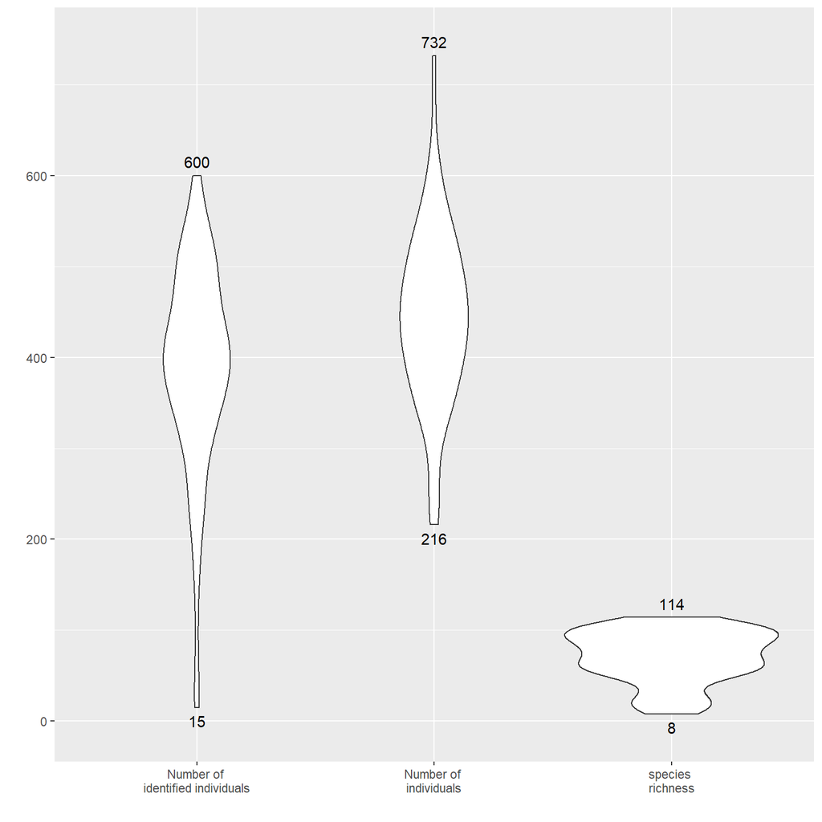

Distribution of sampling and species richness across plots (number of individuals identified to species level, total number of individuals and species richness).

## Fréquences et abondances des espèces

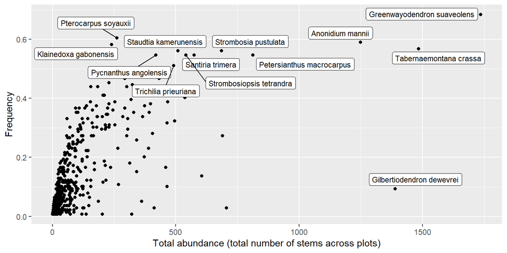

Relation between species frequency across plots and total abundance (total number of stems across plots)

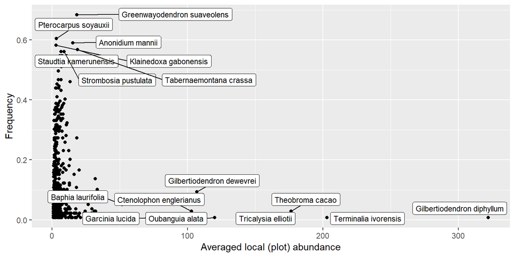

Relation between species frequency across plots and averaged plot abundance in which species occurs

## Etiquette en aluminium sur un *Erythrina excelsa*

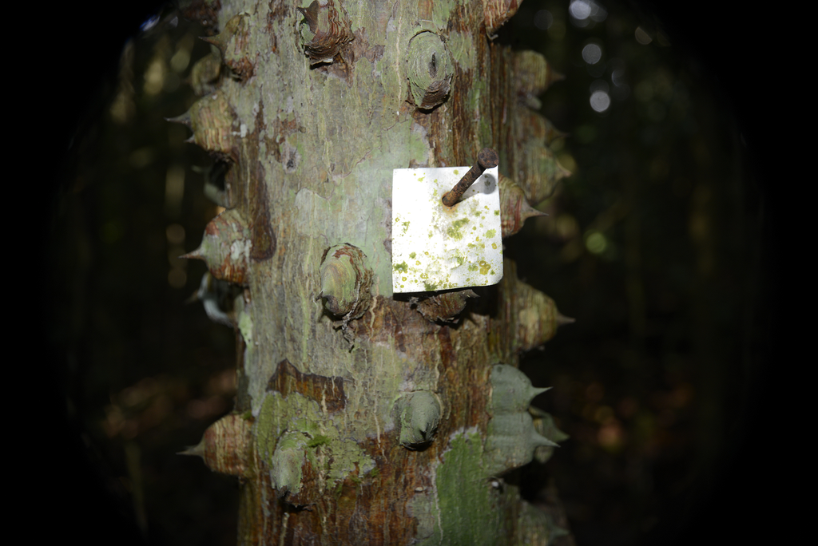

## Distribution spatiale des données

[interactive chart not shown]

## Meta-données

| plot_name | team_leader | additional_people | country | province | locality_name | ddlat | ddlon | date_y | date_m | data_d | number_of_census |
| --- | --- | --- | --- | --- | --- | --- | --- | --- | --- | --- | --- |
| AbongMbang001 | Cohen S. | Ayol T., Cosio A., Mofack G., Mogue S. | Cameroun | east | AbongMbang | 4.18364 | 13.1056 | 2016 |  |  | 1 |
| AbongMbang002 | Cohen S. | Ayol T., Cosio A., Mofack G., Mogue S. | Cameroun | east | AbongMbang | 4.18674 | 13.1096 | 2016 |  |  | 1 |
| AbongMbang003 | Cohen S. | Ayol T., Mofack G., Ngana O. | Cameroun | east | AbongMbang | 4.20646 | 13.1082 | 2016 |  |  | 1 |
| AbongMbang004 | Cohen S. | Ayol T., Mofack G., Ngana O. | Cameroun | east | AbongMbang | 4.2014 | 13.1067 | 2016 |  |  | 1 |
| AbongMbang005 | Cohen S. | Ayol T., Mofack G., Ngana O. | Cameroun | east | AbongMbang | 4.1875 | 13.115 | 2016 |  |  | 1 |
| AlpiCam001 | Ploton P. | Droissart V. Moses L. | Cameroun | east | Alpicam | 3.67155 | 14.7112 | 2013 | 2 | 28 | 1 |
| AlpiCam002 | Ploton P. | Droissart V. Moses L. | Cameroun | east | Alpicam | 3.68437 | 14.7054 | 2013 | 3 | 2 | 1 |
| AlpiCam003 | Ploton P. | Droissart V. Moses L. | Cameroun | east | Alpicam | 3.68022 | 14.7023 | 2013 | 3 | 5 | 1 |
| AlpiCam004 | Droissart V. | Moses L., Deblauwe V. | Cameroun | east | AlpiCam | 3.68774 | 14.681 | 2013 | 5 | 20 | 1 |
| AlpiCam005 | Droissart V. | Moses L., Deblauwe V. | Cameroun | east | AlpiCam | 3.68764 | 14.694 | 2013 | 5 | 20 | 1 |

[output cut: 129 more lines]

## Remesures

- Un deuxième census est disponible pour 16 parcelles.
- Un troisième census est disponible pour 2 parcelles.

## Stats démographiques

- Dates manquantes pour certains census
- Quelques incohérences dans les données restent à résoudre.

| plot_name | census | growth rate (mm/y) | nbe dead | mean dbh of deads | nbe recruits | mean dbh of recruits | max dbh of recruits | number of stem assessed | number of stem excluded | sd growth rate | mean dbh of all stems census 1 | mean dbh of all stems census 2 | number of days between census | date census 1 | date census 2 |
| --- | --- | --- | --- | --- | --- | --- | --- | --- | --- | --- | --- | --- | --- | --- | --- |
| DengDeng001 | census_1_census_2 | 2.22 | 8 | 15.4 | 0 |  |  | 557 | 6 | 3.46 | 257.78 | 264.44 | 1096 | 1Jul2011 | 1Jul2014 |
| DengDeng001 | census_2_census_3 | 1.69 | 3 | 15.83 | 52 | 11.7 | 20.3 | 547 | 13 | 3.43 | 264.95 | 267.92 | 640 | 1Jul2014 | 1Apr2016 |
| DengDeng002 | census_1_census_2 | 2.13 | 16 | 22.85 | 0 |  |  | 517 | 5 | 3.82 | 237.4 | 243.78 | 1096 | 1Jul2011 | 1Jul2014 |
| DengDeng002 | census_2_census_3 | 2.25 | 5 | 18.62 | 27 | 14.25 | 88 | 508 | 9 | 4.84 | 241.29 | 245.22 | 640 | 1Jul2014 | 1Apr2016 |
| DengDeng003 | census_1_census_2 | 14.15 | 28 | 25.23 | 13 | 14.92 | 35.6 | 199 | 198 | 19.9 | 227.66 | 251.72 | 621 | 20Jul2014 | 1Apr2016 |
| DengDeng004 | census_1_census_2 | 6.66 | 11 | 28.33 | 30 | 13.61 | 60.6 | 439 | 145 | 13.5 | 211.43 | 222.74 | 620 | 21Jul2014 | 1Apr2016 |
| DengDeng005 | census_1_census_2 | 2.96 | 13 | 24.18 | 9 | 10.28 | 11 | 479 | 6 | 4.22 | 235.91 | 240.92 | 619 | 22Jul2014 | 1Apr2016 |

## Measures de traits fonctionnels

- Mesures à l’échelle de l’individu: SLA, densité de bois des tiges, essentiellement collecté par Moses Libalah et collègues. Croisement avec les données de plots encore à vérifier car problèmes réccurents dans l’assignation à des tags.
- Attribution à l’échelle de l’espèce: tempérament, densité de bois, décidu/sempervirent. A faire mais données disponibles.